# What Predicts Crime? A Socioeconomic Analysis of US States

Correlation, Multiple Regression & 10-Year Longitudinal Analysis

[MD Noornabi] | Mayerfeld Data Analytics Certificate

March 2026

## Background & Central Question

This analysis uses a dataset of 47 US states measured at two timepoints — **Year 0** and **Year 10** — covering crime rates and 13 socioeconomic variables including wages, education, police expenditure, unemployment, and demographics.

**Three questions drive the analysis:**

1. Which socioeconomic variables significantly predict crime rates?
2. Are the relationships what we’d intuitively expect — or are there paradoxes that require deeper interpretation?
3. How stable are crime rates over a decade — and do the same predictors hold at both timepoints?

## Setup

```r
library(tidyverse)
library(ggplot2)
library(ggcorrplot)
library(gridExtra)
library(moments)
library(scales)

mytheme <- theme_minimal(base_size=13) +
  theme(plot.title=element_text(face="bold",size=14,color="#1F4E79"),
        plot.subtitle=element_text(color="grey40",size=11),
        plot.caption=element_text(color="grey55",size=9,face="italic"),
        panel.grid.minor=element_blank())

cohens_d <- function(x,y) (mean(x)-mean(y)) / sqrt((sd(x)^2+sd(y)^2)/2)
```

```r
crime <- read.csv("data/Crime.csv")
crime$Southern       <- factor(crime$Southern,       levels=c(0,1), labels=c("Non-Southern","Southern"))
crime$MoreMales      <- factor(crime$MoreMales,       levels=c(0,1), labels=c("No","Yes"))
crime$HighYouthUnemploy <- factor(crime$HighYouthUnemploy, levels=c(0,1), labels=c("Low","High"))
crime$LogExpenditure <- log(crime$ExpenditureYear0)
crime$CrimeChange    <- crime$CrimeRate10 - crime$CrimeRate
cat("n =", nrow(crime), "states  |  Variables:", ncol(crime))
```

```
## n = 47 states  |  Variables: 29
```

## 1. Exploratory Data Analysis

### Crime Rate Overview

```r
data.frame(
  Timepoint = c("Year 0","Year 10"),
  Mean      = round(c(mean(crime$CrimeRate),mean(crime$CrimeRate10)),2),
  Median    = round(c(median(crime$CrimeRate),median(crime$CrimeRate10)),2),
  SD        = round(c(sd(crime$CrimeRate),sd(crime$CrimeRate10)),2),
  Min       = c(min(crime$CrimeRate),min(crime$CrimeRate10)),
  Max       = c(max(crime$CrimeRate),max(crime$CrimeRate10))
)
```

| Timepoint | Mean | Median | SD | Min | Max |
| --- | --- | --- | --- | --- | --- |
| Year 0 | 102.81 | 103.0 | 28.89 | 45.5 | 161.8 |
| Year 10 | 102.07 | 103.5 | 39.28 | 26.5 | 178.2 |

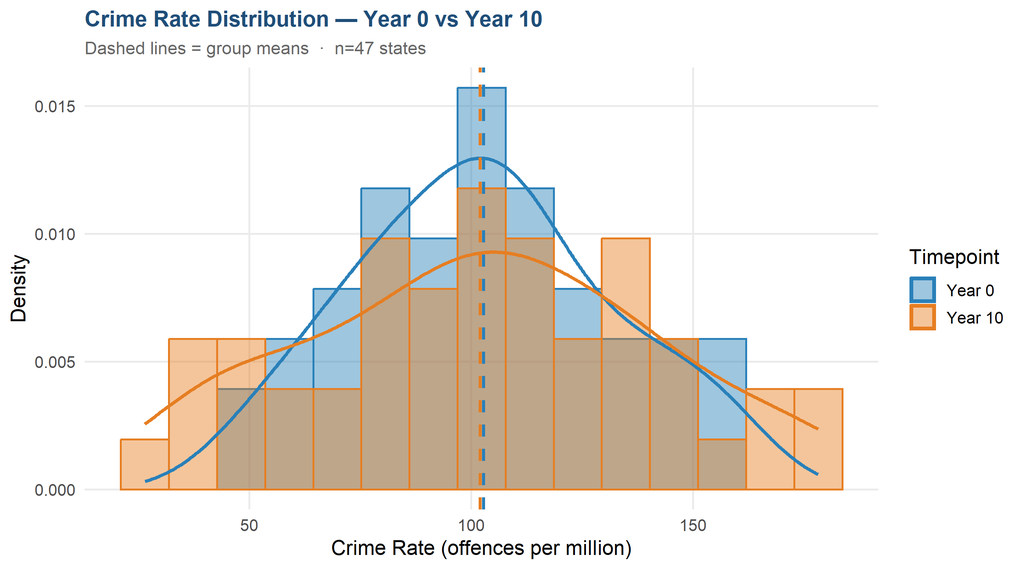

```r
cr_long <- data.frame(
  CrimeRate = c(crime$CrimeRate,crime$CrimeRate10),
  Timepoint = rep(c("Year 0","Year 10"),each=nrow(crime))
)
ggplot(cr_long, aes(CrimeRate,fill=Timepoint,color=Timepoint)) +
  geom_histogram(aes(y=after_stat(density)),bins=15,alpha=0.45,position="identity") +
  geom_density(linewidth=1.1,alpha=0) +
  geom_vline(xintercept=mean(crime$CrimeRate),  linetype="dashed",color="#2980b9",linewidth=0.9) +
  geom_vline(xintercept=mean(crime$CrimeRate10),linetype="dashed",color="#e67e22",linewidth=0.9) +
  scale_fill_manual(values=c("Year 0"="#2980b9","Year 10"="#e67e22")) +
  scale_color_manual(values=c("Year 0"="#2980b9","Year 10"="#e67e22")) +
  labs(title="Crime Rate Distribution — Year 0 vs Year 10",
       subtitle="Dashed lines = group means  ·  n=47 states",
       x="Crime Rate (offences per million)",y="Density") + mytheme
```

### Handling Skewed Variables

```r
data.frame(
  Variable      = c("ExpenditureYear0","Log(ExpenditureYear0)","YouthUnemployment","Log(YouthUnemployment)"),
  Skewness      = round(c(skewness(crime$ExpenditureYear0),
                           skewness(log(crime$ExpenditureYear0)),
                           skewness(crime$YouthUnemployment),
                           skewness(log(crime$YouthUnemployment))),4),
  Action        = c("Log-transformed","✓ Used in regression","Noted","Not needed — not in final model")
)
```

| Variable | Skewness | Action |
| --- | --- | --- |
| ExpenditureYear0 | 0.9193 | Log-transformed |
| Log(ExpenditureYear0) | 0.2841 | ✓ Used in regression |
| YouthUnemployment | 0.8003 | Noted |
| Log(YouthUnemployment) | 0.4581 | Not needed — not in final model |

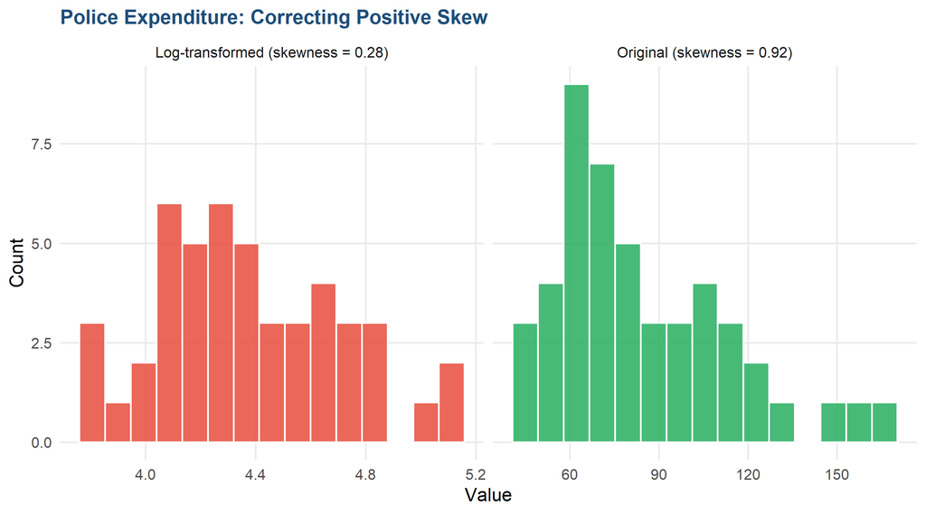

Figure 2: Log transformation substantially reduces right skew in police expenditure, making it more appropriate for regression.

```r
exp_df <- data.frame(
  Value = c(crime$ExpenditureYear0,log(crime$ExpenditureYear0)),
  Type  = rep(c("Original (skewness = 0.92)","Log-transformed (skewness = 0.28)"),each=nrow(crime))
)
ggplot(exp_df, aes(Value,fill=Type)) +
  geom_histogram(bins=15,alpha=0.85,color="white") +
  facet_wrap(~Type,scales="free_x") +
  scale_fill_manual(values=c("#e74c3c","#27ae60")) +
  labs(title="Police Expenditure: Correcting Positive Skew",
       x="Value",y="Count") +
  mytheme + theme(legend.position="none")
```

## 2. Correlation Analysis: What Predicts Crime?

```r
cont_vars <- c("Youth","Education","ExpenditureYear0","LabourForce","Males",
               "StateSize","YouthUnemployment","MatureUnemployment","Wage","BelowWage")
map_dfr(cont_vars, function(v) {
  ct <- cor.test(crime[[v]], crime$CrimeRate)
  tibble(Variable=v, r=round(ct$estimate,4), p=round(ct$p.value,4),
         Significant=ifelse(ct$p.value<0.05,"Yes **","No"))
}) %>% arrange(desc(abs(r)))
```

| Variable | r | p | Significant |
| --- | --- | --- | --- |
| ExpenditureYear0 | 0.6462 | 0.0000 | Yes ** |
| Wage | 0.4249 | 0.0029 | Yes ** |
| StateSize | 0.3079 | 0.0352 | Yes ** |
| MatureUnemployment | 0.1718 | 0.2481 | No |
| LabourForce | 0.1693 | 0.2552 | No |
| BelowWage | -0.1673 | 0.2610 | No |
| Males | 0.1571 | 0.2916 | No |
| Education | 0.1570 | 0.2919 | No |
| Youth | -0.0550 | 0.7135 | No |
| YouthUnemployment | -0.0506 | 0.7355 | No |

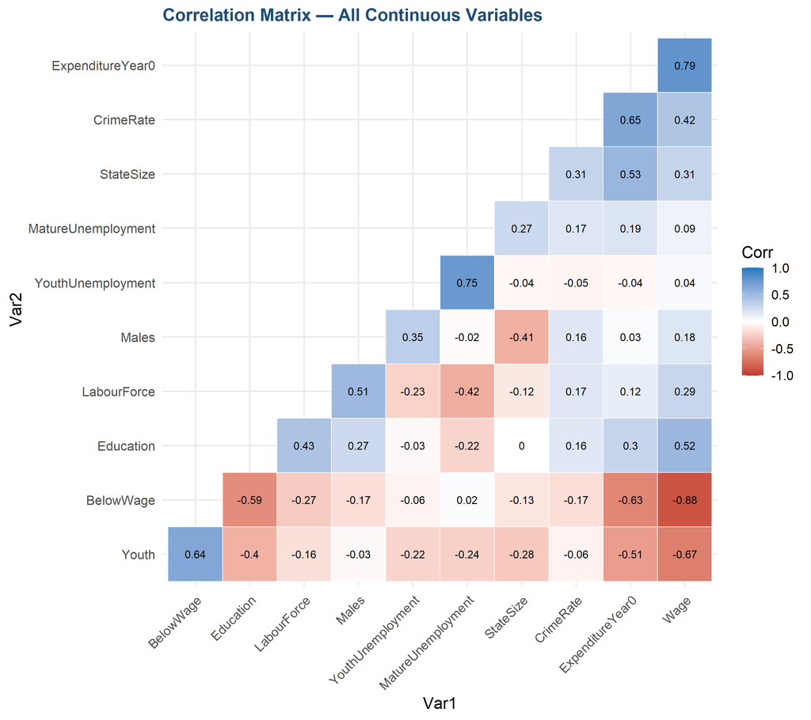

Figure 3: Correlation heatmap with hierarchical clustering. Police expenditure and wage are the strongest crime correlates. Note the very strong negative correlation between Wage and BelowWage (r = -0.88).

```r
all_cont <- crime %>% select(CrimeRate,Youth,Education,ExpenditureYear0,LabourForce,
                               Males,StateSize,YouthUnemployment,MatureUnemployment,Wage,BelowWage)
ggcorrplot(cor(all_cont), hc.order=TRUE, type="lower", lab=TRUE, lab_size=3,
           colors=c("#c0392b","white","#1a7abf"), outline.color="white",
           title="Correlation Matrix — All Continuous Variables") +
  mytheme + theme(axis.text.x=element_text(angle=45,hjust=1))
```

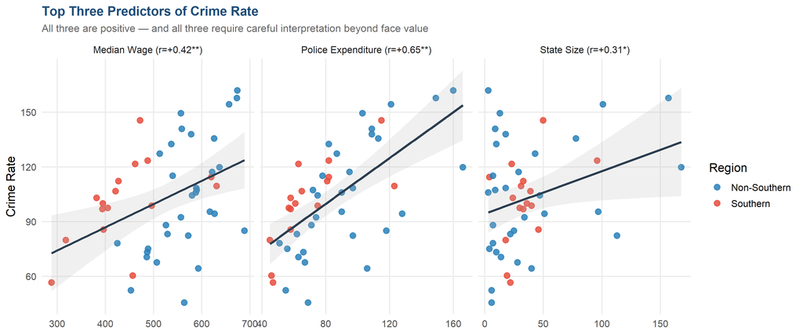

Figure 4: The three significant continuous predictors of crime rate. All show positive relationships — each is counterintuitive and requires interpretation.

```r
top3 <- crime %>%
  select(CrimeRate,ExpenditureYear0,Wage,StateSize,Southern) %>%
  pivot_longer(c(ExpenditureYear0,Wage,StateSize),names_to="Predictor",values_to="Value") %>%
  mutate(Predictor=recode(Predictor,
    "ExpenditureYear0"="Police Expenditure (r=+0.65**)",
    "Wage"="Median Wage (r=+0.42**)",
    "StateSize"="State Size (r=+0.31*)"))
ggplot(top3, aes(Value,CrimeRate,color=Southern)) +
  geom_point(size=2.8,alpha=0.85) +
  geom_smooth(method="lm",se=TRUE,aes(group=1),color="#2c3e50",fill="grey70",alpha=0.2) +
  facet_wrap(~Predictor,scales="free_x") +
  scale_color_manual(values=c("Non-Southern"="#2980b9","Southern"="#e74c3c")) +
  labs(title="Top Three Predictors of Crime Rate",
       subtitle="All three are positive — and all three require careful interpretation beyond face value",
       x=NULL,y="Crime Rate",color="Region") + mytheme
```

## 3. The Three Paradoxes

### Paradox 1 — Police Expenditure: Spending Cause Crime or Respond to It?

The strongest predictor of crime is police expenditure (r = +0.65). At first glance this seems absurd — more police spending leads to more crime? The obvious alternative is **reverse causation**: high-crime states spend more on policing *because* of high crime.

But we can test this. If reverse causation fully explains the relationship, then **Year 0 spending should not predict Year 10 crime** — because the spending is responding to current crime, not causing future crime.

```r
data.frame(
  Test = c("Exp(Year 0) vs Crime(Year 0)","Exp(Year 0) vs Crime(Year 10)"),
  r    = round(c(cor(crime$ExpenditureYear0,crime$CrimeRate),
                  cor(crime$ExpenditureYear0,crime$CrimeRate10)),4),
  p    = round(c(cor.test(crime$ExpenditureYear0,crime$CrimeRate)$p.value,
                  cor.test(crime$ExpenditureYear0,crime$CrimeRate10)$p.value),4)
)
```

| Test | r | p |
| --- | --- | --- |
| Exp(Year 0) vs Crime(Year 0) | 0.6462 | 0 |
| Exp(Year 0) vs Crime(Year 10) | 0.6435 | 0 |

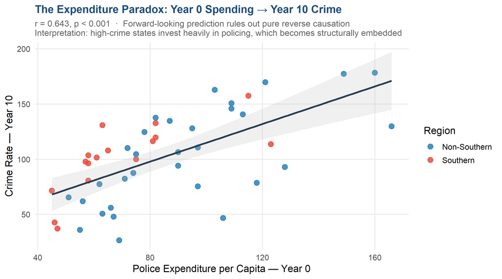

Figure 5: Year 0 police expenditure predicts Year 10 crime almost as strongly as Year 0 crime. Pure reverse causation cannot explain this forward-looking relationship.

```r
r_exp10 <- round(cor(crime$ExpenditureYear0,crime$CrimeRate10),3)
ggplot(crime, aes(ExpenditureYear0,CrimeRate10,color=Southern)) +
  geom_point(size=3,alpha=0.85) +
  geom_smooth(method="lm",se=TRUE,aes(group=1),color="#2c3e50",fill="grey70",alpha=0.2) +
  scale_color_manual(values=c("Non-Southern"="#2980b9","Southern"="#e74c3c")) +
  labs(title="The Expenditure Paradox: Year 0 Spending → Year 10 Crime",
       subtitle=paste0("r = ",r_exp10,", p < 0.001  ·  Forward-looking prediction rules out pure reverse causation\n",
                       "Interpretation: high-crime states invest heavily in policing, which becomes structurally embedded"),
       x="Police Expenditure per Capita — Year 0",y="Crime Rate — Year 10",color="Region") + mytheme
```

> **Interpretation:** The relationship is likely **bidirectional and structural**. High-crime states invest more in policing. That investment becomes embedded in state infrastructure. States with historically high crime maintain high expenditure — and high crime — over time.

### Paradox 2 — Wage: Does Prosperity Drive Crime?

Higher wages are associated with more crime (r = +0.42). But the same states with higher wages have dramatically fewer families below the poverty line (r = −0.88 between Wage and BelowWage).

```r
data.frame(
  Relationship = c("Wage vs CrimeRate","BelowWage vs CrimeRate","Wage vs BelowWage"),
  r = round(c(cor(crime$Wage,crime$CrimeRate),
               cor(crime$BelowWage,crime$CrimeRate),
               cor(crime$Wage,crime$BelowWage)),4),
  p = round(c(cor.test(crime$Wage,crime$CrimeRate)$p.value,
               cor.test(crime$BelowWage,crime$CrimeRate)$p.value,
               cor.test(crime$Wage,crime$BelowWage)$p.value),4)
)
```

| Relationship | r | p |
| --- | --- | --- |
| Wage vs CrimeRate | 0.4249 | 0.0029 |
| BelowWage vs CrimeRate | -0.1673 | 0.2610 |
| Wage vs BelowWage | -0.8840 | 0.0000 |

> **Interpretation:** Wage is a proxy for **urbanisation**. High-wage states tend to be more urban. Urban areas have higher crime rates (more density, more opportunity, more reporting) — but they also have greater prosperity and less poverty. Wage is not a direct driver of crime; it’s a confounding variable capturing the urban/rural dimension.

### Paradox 3 — Education: Why Doesn’t Education Reduce Crime?

```r
data.frame(
  Test = c("Education(t0) vs Crime(t0)","Education(t10) vs Crime(t10)"),
  r    = round(c(cor(crime$Education,crime$CrimeRate),
                  cor(crime$Education10,crime$CrimeRate10)),4),
  p    = round(c(cor.test(crime$Education,crime$CrimeRate)$p.value,
                  cor.test(crime$Education10,crime$CrimeRate10)$p.value),4),
  Direction = c("Positive (!)","Positive (!)")
)
```

| Test | r | p | Direction |
| --- | --- | --- | --- |
| Education(t0) vs Crime(t0) | 0.157 | 0.2919 | Positive (!) |
| Education(t10) vs Crime(t10) | 0.128 | 0.3911 | Positive (!) |

> More education is slightly (non-significantly) associated with more crime at both timepoints — the same urbanisation confound. More educated states tend to be more urban. The direct protective effect of education is masked by this confounding relationship.

## 4. Group Comparisons

### Southern vs Non-Southern States

```r
vars_comp <- c("CrimeRate","Wage","Education","ExpenditureYear0","BelowWage")
map_dfr(vars_comp, function(v) {
  s  <- crime %>% filter(Southern=="Southern") %>% pull(v)
  ns <- crime %>% filter(Southern=="Non-Southern") %>% pull(v)
  tt <- t.test(s, ns, var.equal=FALSE)
  tibble(Variable=v,
         `South Mean`=round(mean(s),2),
         `NonSouth Mean`=round(mean(ns),2),
         `p-value`=round(tt$p.value,4),
         `Cohen's d`=round(abs(cohens_d(s,ns)),3),
         Significant=ifelse(tt$p.value<0.05,"Yes **","No"))
})
```

| Variable | South Mean | NonSouth Mean | p-value | Cohen's d | Significant |
| --- | --- | --- | --- | --- | --- |
| CrimeRate | 100.68 | 103.91 | 0.6909 | 0.117 | No |
| Wage | 440.75 | 569.06 | 0.0000 | 1.613 | Yes ** |
| Education | 11.62 | 12.79 | 0.0006 | 1.182 | Yes ** |
| ExpenditureYear0 | 69.75 | 92.87 | 0.0054 | 0.866 | Yes ** |
| BelowWage | 234.50 | 173.10 | 0.0000 | 2.166 | Yes ** |

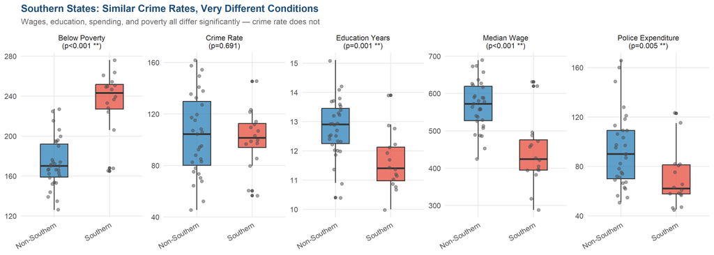

Figure 6: Southern states show similar crime rates to non-Southern states but dramatically worse socioeconomic conditions across every measured variable.

```r
south_long <- crime %>%
  select(Southern,CrimeRate,Wage,Education,ExpenditureYear0,BelowWage) %>%
  pivot_longer(-Southern,names_to="Variable",values_to="Value") %>%
  mutate(Variable=recode(Variable,
    "CrimeRate"="Crime Rate\n(p=0.691)",
    "Wage"="Median Wage\n(p<0.001 **)",
    "Education"="Education Years\n(p=0.001 **)",
    "ExpenditureYear0"="Police Expenditure\n(p=0.005 **)",
    "BelowWage"="Below Poverty\n(p<0.001 **)"))
ggplot(south_long, aes(Southern,Value,fill=Southern)) +
  geom_boxplot(alpha=0.75,width=0.5) +
  geom_jitter(width=0.12,alpha=0.5,size=1.8,color="grey30") +
  facet_wrap(~Variable,scales="free_y",nrow=1) +
  scale_fill_manual(values=c("Non-Southern"="#2980b9","Southern"="#e74c3c")) +
  labs(title="Southern States: Similar Crime Rates, Very Different Conditions",
       subtitle="Wages, education, spending, and poverty all differ significantly — crime rate does not",
       x=NULL,y=NULL) +
  mytheme + theme(legend.position="none",axis.text.x=element_text(angle=30,hjust=1))
```

> **Key insight:** Southern states have lower wages, less education, lower police expenditure, and more families in poverty — yet their crime rates are not significantly higher. This suggests that crime rate is determined by a complex combination of factors that don’t reduce to simple economic disadvantage, and that the structural embedding of crime patterns (see Section 6) may be as important as current conditions.

### High vs Low Youth Unemployment

```r
high <- crime %>% filter(HighYouthUnemploy=="High")
low  <- crime %>% filter(HighYouthUnemploy=="Low")
tt   <- t.test(high$CrimeRate, low$CrimeRate, var.equal=FALSE)
cat(sprintf("High (n=%d): mean=%.1f  |  Low (n=%d): mean=%.1f\nt=%.3f  p=%.3f  d=%.3f",
            nrow(high), mean(high$CrimeRate), nrow(low), mean(low$CrimeRate),
            tt$statistic, tt$p.value, abs(cohens_d(high$CrimeRate, low$CrimeRate))))
```

```
## High (n=15): mean=90.9  |  Low (n=32): mean=108.4
## t=-1.948  p=0.062  d=0.618
```

> Borderline result (p = 0.062) with a medium effect size (d ≈ 0.60). This is likely a **Type II error** — the sample of 47 states is insufficient to reliably detect a moderate group difference. With a larger dataset, this would likely reach significance.

## 5. Multiple Linear Regression

### Building the Model

```r
model <- lm(CrimeRate ~ LogExpenditure + Wage + StateSize + BelowWage, data=crime)
summary(model)
```

```
##
## Call:
## lm(formula = CrimeRate ~ LogExpenditure + Wage + StateSize +
##     BelowWage, data = crime)
##
## Residuals:
##     Min      1Q  Median      3Q     Max
## -56.064 -11.582   2.533  12.249  31.839
##
## Coefficients:
##                  Estimate Std. Error t value Pr(>|t|)
## (Intercept)    -441.53199   75.27136  -5.866 6.19e-07 ***
## LogExpenditure   86.35176   16.47156   5.242 4.83e-06 ***
## Wage              0.11043    0.08277   1.334  0.18932
## StateSize        -0.14614    0.08694  -1.681  0.10022
## BelowWage         0.58163    0.15572   3.735  0.00056 ***
## ---
## Signif. codes:  0 '***' 0.001 '**' 0.01 '*' 0.05 '.' 0.1 ' ' 1
##
## Residual standard error: 18.5 on 42 degrees of freedom
## Multiple R-squared:  0.6257, Adjusted R-squared:   0.59
## F-statistic: 17.55 on 4 and 42 DF,  p-value: 1.546e-08
```

```r
sw <- shapiro.test(residuals(model))
cat(sprintf("Shapiro-Wilk on residuals: W=%.4f  p=%.4f  [%s]",
            sw$statistic, sw$p.value, ifelse(sw$p.value>0.05,"Normal ✓","Not Normal ✗")))
```

```
## Shapiro-Wilk on residuals: W=0.9636  p=0.1488  [Normal ✓]
```

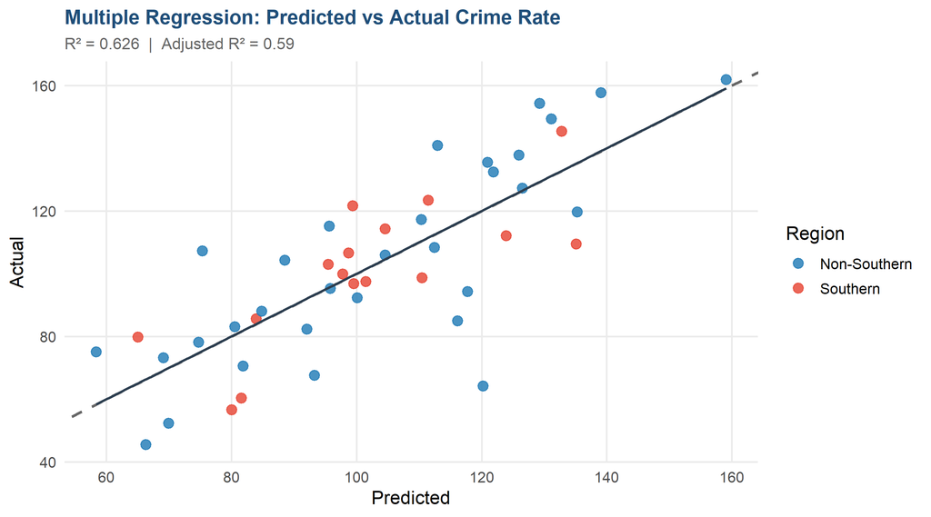

```r
crime$predicted <- fitted(model)
ggplot(crime, aes(predicted,CrimeRate,color=Southern)) +
  geom_point(size=3,alpha=0.85) +
  geom_abline(slope=1,intercept=0,linetype="dashed",color="grey40",linewidth=1) +
  geom_smooth(method="lm",se=FALSE,aes(group=1),color="#2c3e50",linewidth=0.8) +
  scale_color_manual(values=c("Non-Southern"="#2980b9","Southern"="#e74c3c")) +
  labs(title="Multiple Regression: Predicted vs Actual Crime Rate",
       subtitle=paste0("R² = ",round(summary(model)$r.squared,3),
                       "  |  Adjusted R² = ",round(summary(model)$adj.r.squared,3)),
       x="Predicted",y="Actual",color="Region") + mytheme
```

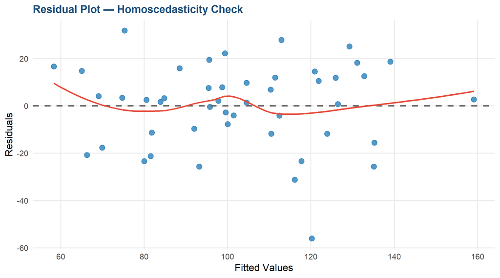

Figure 8: Residuals show roughly even spread — homoscedasticity is approximately satisfied.

```r
crime$residuals <- residuals(model)
ggplot(crime, aes(predicted,residuals)) +
  geom_point(color="#2980b9",size=3,alpha=0.8) +
  geom_hline(yintercept=0,linetype="dashed",color="grey40",linewidth=1) +
  geom_smooth(se=FALSE,color="#e74c3c",linewidth=0.9) +
  labs(title="Residual Plot — Homoscedasticity Check",
       x="Fitted Values",y="Residuals") + mytheme
```

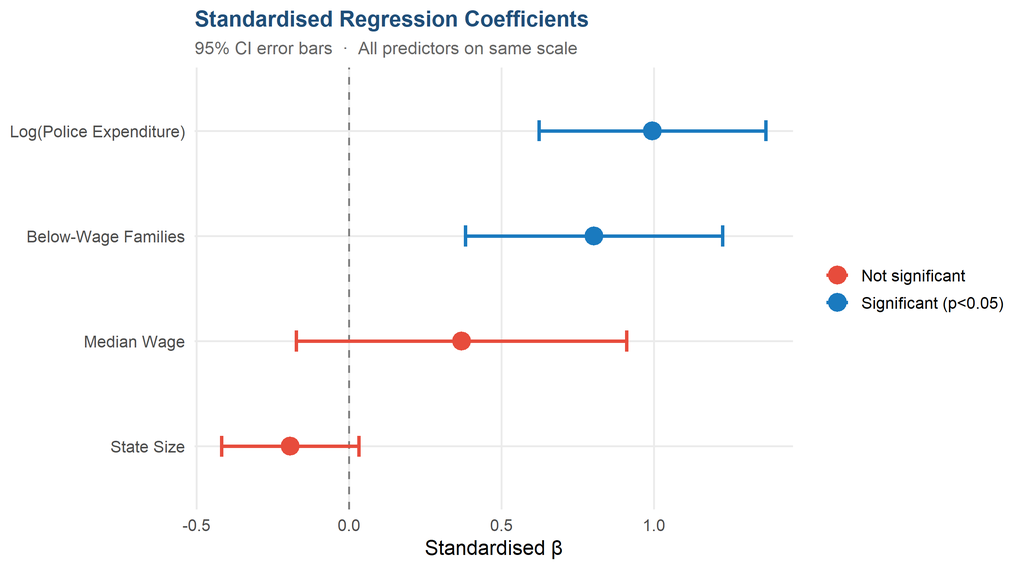

```r
std_model <- lm(scale(CrimeRate) ~ scale(LogExpenditure)+scale(Wage)+
                  scale(StateSize)+scale(BelowWage), data=crime)
coef_df <- data.frame(
  Predictor = c("Log(Police Expenditure)","Median Wage","State Size","Below-Wage Families"),
  Beta      = coef(std_model)[-1],
  SE        = summary(std_model)$coefficients[-1,2],
  p_val     = summary(std_model)$coefficients[-1,4]
) %>% mutate(
  Significant=ifelse(p_val<0.05,"Significant (p<0.05)","Not significant")
) %>% arrange(abs(Beta))
coef_df$Predictor <- factor(coef_df$Predictor,levels=coef_df$Predictor)

ggplot(coef_df, aes(Beta,Predictor,color=Significant)) +
  geom_vline(xintercept=0,linetype="dashed",color="grey50") +
  geom_errorbarh(aes(xmin=Beta-1.96*SE,xmax=Beta+1.96*SE),height=0.2,linewidth=1.1) +
  geom_point(size=5) +
  scale_color_manual(values=c("Significant (p<0.05)"="#1a7abf","Not significant"="#e74c3c")) +
  labs(title="Standardised Regression Coefficients",
       subtitle="95% CI error bars  ·  All predictors on same scale",
       x="Standardised β",y=NULL,color=NULL) + mytheme
```

### Model Summary

| Metric | Value |
| --- | --- |
| R² | 0.626 |
| Adjusted R² | 0.59 |
| Residuals normal (Shapiro-Wilk) | Yes ✓ |
| Dominant predictor | Log(Police Expenditure) |

> Four predictors explain **62.6%** of variance in state crime rates. This is a strong result for observational social science data. The dominant predictor — log(police expenditure) — reflects the structural embedding discussed in Paradox 1.

## 6. Longitudinal Analysis: 10-Year Persistence

### Did Crime Rates Change Overall?

```r
tt_long <- t.test(crime$CrimeRate, crime$CrimeRate10, paired=TRUE)
cat(sprintf("Paired t-test: t=%.3f  p=%.3f\nMean change: %.2f  SD: %.2f\nIncreased: %d/47  Decreased: %d/47",
            tt_long$statistic, tt_long$p.value,
            mean(crime$CrimeChange), sd(crime$CrimeChange),
            sum(crime$CrimeChange>0), sum(crime$CrimeChange<0)))
```

```
## Paired t-test: t=0.471  p=0.640
## Mean change: -0.74  SD: 10.75
## Increased: 27/47  Decreased: 20/47
```

No significant overall change (p = 0.640) — but 27 states increased and 20 decreased, with the average change near zero.

### The Persistence Finding

```r
r_persist <- cor.test(crime$CrimeRate, crime$CrimeRate10)
cat(sprintf("r = %.4f  p < 0.001", r_persist$estimate))
```

```
## r = 0.9966  p < 0.001
```

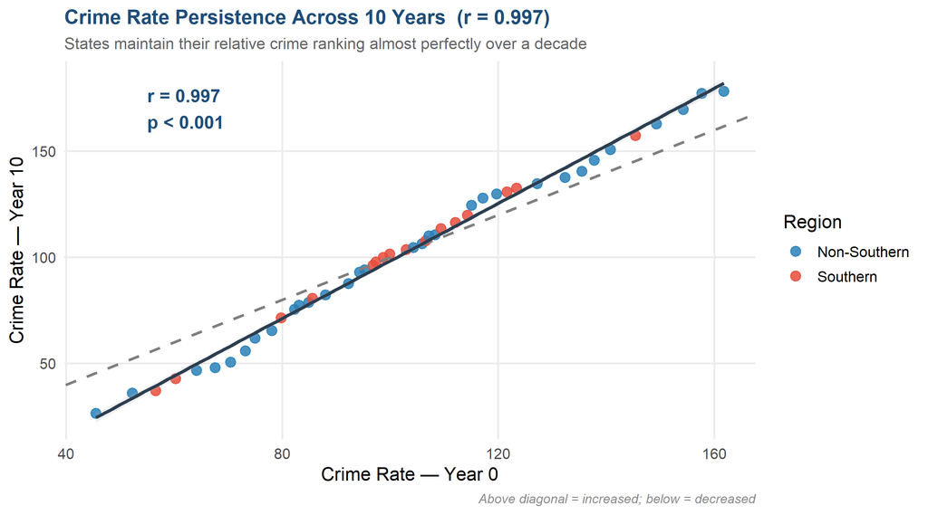

Figure 10: Near-perfect correlation between Year 0 and Year 10 crime rates. A state’s crime rank is essentially locked in — structural change is minimal over a decade.

```r
ggplot(crime, aes(CrimeRate,CrimeRate10,color=Southern)) +
  geom_point(size=3,alpha=0.85) +
  geom_abline(slope=1,intercept=0,linetype="dashed",color="grey50",linewidth=1) +
  geom_smooth(method="lm",se=TRUE,aes(group=1),color="#2c3e50",fill="grey70",alpha=0.2) +
  scale_color_manual(values=c("Non-Southern"="#2980b9","Southern"="#e74c3c")) +
  annotate("text",x=55,y=170,
           label=paste0("r = ",round(r_persist$estimate,3),"\np < 0.001"),
           size=4.5,color="#1F4E79",fontface="bold",hjust=0) +
  labs(title=paste0("Crime Rate Persistence Across 10 Years  (r = ",
                    round(r_persist$estimate,3),")"),
       subtitle="States maintain their relative crime ranking almost perfectly over a decade",
       x="Crime Rate — Year 0",y="Crime Rate — Year 10",
       caption="Above diagonal = increased; below = decreased",
       color="Region") + mytheme
```

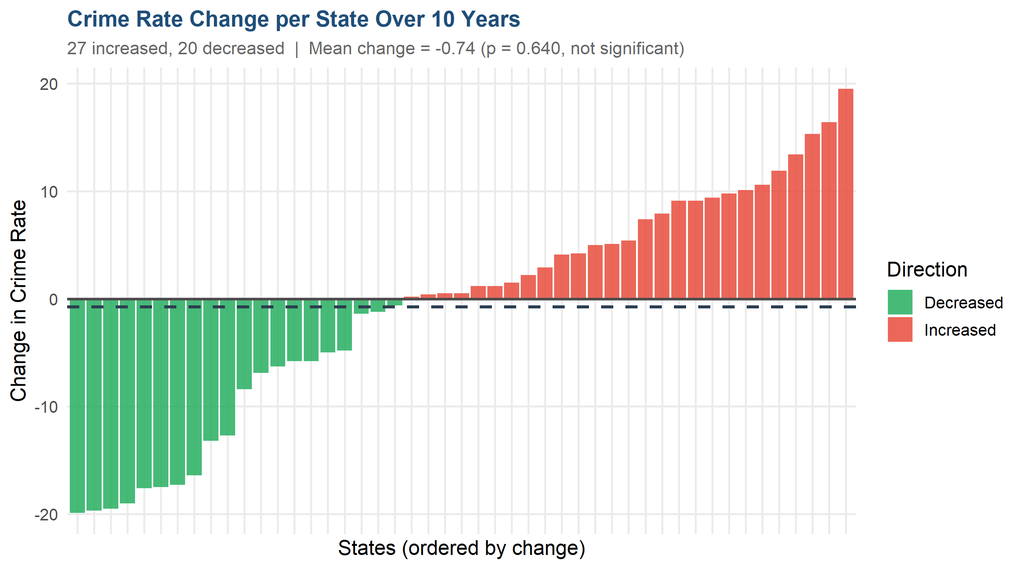

Figure 11: Individual state changes are modest and roughly balanced — no systemic direction of change, consistent with the non-significant paired t-test.

```r
crime %>%
  mutate(State=row_number(),
         Direction=ifelse(CrimeChange>0,"Increased","Decreased")) %>%
  ggplot(aes(x=reorder(State,CrimeChange),y=CrimeChange,fill=Direction)) +
  geom_col(alpha=0.85) +
  geom_hline(yintercept=0,color="grey30",linewidth=0.8) +
  geom_hline(yintercept=mean(crime$CrimeChange),linetype="dashed",color="#2c3e50",linewidth=1) +
  scale_fill_manual(values=c("Increased"="#e74c3c","Decreased"="#27ae60")) +
  labs(title="Crime Rate Change per State Over 10 Years",
       subtitle=paste0("27 increased, 20 decreased  |  Mean change = ",
                       round(mean(crime$CrimeChange),2)," (p = 0.640, not significant)"),
       x="States (ordered by change)",y="Change in Crime Rate",fill="Direction") +
  mytheme + theme(axis.text.x=element_blank(),axis.ticks.x=element_blank())
```

## 7. Summary of Findings

[output not shown]

*Analysis in R — tidyverse, ggplot2, ggcorrplot. Mayerfeld Data Analytics Certificate — Week 3.*